# Week 1 seminar

Joshua Loftus

1/22/2021

## Repeating the gapminder analysis

Let’s start easy by just repeating some steps but with data from a different year.

### Create the `gapminder` scatterplot using data from the year 2002

```r
gm2002 <- gapminder %>%
  filter(year == 2002)
```

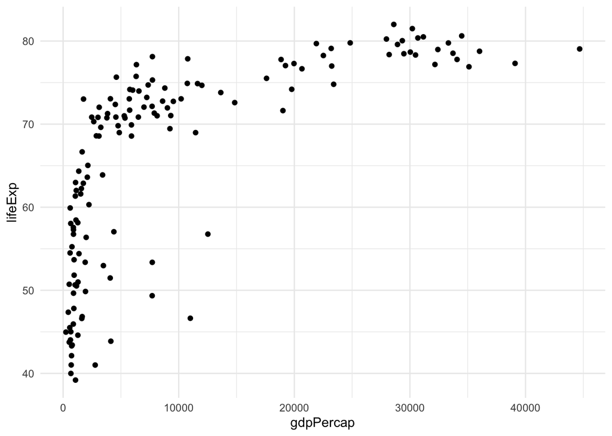

```r
gm_scatterplot <-
  ggplot(gm2002,
         aes(x = gdpPercap, y = lifeExp)) +
  geom_point()
gm_scatterplot
```

#### Create an lm model to predict lifeExp

```r
model_lm <- lm(lifeExp ~ gdpPercap, data = gm2002)
predictions_lm <- augment(model_lm)
```

#### Create a loess model to predict lifeExp

```r
model_loess <- loess(lifeExp ~ gdpPercap, span = .75, data = gm2002)
predictions_loess <- augment(model_loess)
```

#### Plot showing the two models

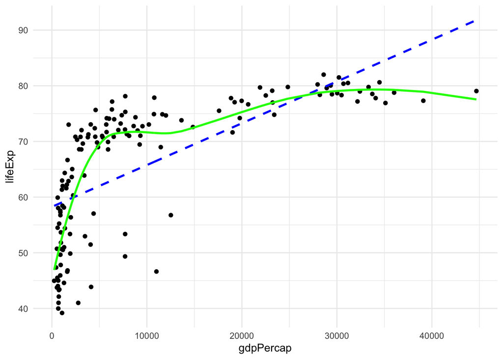

```r
gm_scatterplot +
  geom_line(data = predictions_lm, size = 1,
            color = "blue",
            linetype = "dashed",
            aes(y = .fitted)) +
  geom_line(data = predictions_loess, size = 1,
            color = "green",
            aes(y = .fitted))
```

```r
mean(residuals(model_lm)^2)
```

```
## [1] 80.11716
```

```r
mean(residuals(model_loess)^2)
```

```
## [1] 45.21583
```

## Predicting on new data

Models are supposed to capture/use structure in the data that corresponds to structure in the real world. And if the real world isn’t misbehaving, that structure should be somewhat stable.

For example, suppose the relationship changed dramatically from one time period to another time period. Then it would be less useful/interesting to have a model fit on data at one time period, because the same model might have a poor fit on data from a different time period.

Let’s explore this with our `gapminder` models

#### Predictions on different years

Create datasets for the desired years

```r
gm2007 <- gapminder %>% filter(year == 2007)
gm1997 <- gapminder %>% filter(year == 1997)
```

Predict using `newdata` argument, then `pull` the residuals from the resulting data.frame

```r
lm_resid2007 <- augment(model_lm, newdata = gm2007) %>%
  pull(.resid)
lm_resid1997 <- augment(model_lm, newdata = gm1997) %>%
  pull(.resid)
loess_resid2007 <- augment(model_loess, newdata = gm2007) %>%
  pull(.resid)
loess_resid1997 <- augment(model_loess, newdata = gm1997) %>%
  pull(.resid)
```

#### Check 1997

```r
mean(lm_resid1997^2)
```

```
## [1] 67.23804
```

```r
mean(loess_resid1997^2)
```

```
## [1] 31.56738
```

#### Check 2007

```r
mean(lm_resid2007^2)
```

```
## [1] 80.1876
```

```r
mean(loess_resid2007^2, na.rm = TRUE)
```

```
## [1] 49.54716
```

One trade-off we see here: the `loess` function does not have any default way of extrapolating to observations outside the range of the original data (values of `gdpPercap` in 2007 that are larger than the maximum in 2002).

## Conclusion/notes

The more complex, `loess` model performs better than the linear model even when tested on data from 5 years earlier or later.

Sometimes a more complex model really is better!

**Question**: Can we break it? Let’s change the `span` parameter in the `loess` function to make it even more complex and see if we keep reaching the same conclusion.

**Answer**: Even after decreasing to `span = 0.1` the more complex model was still better!

**Question**: How can we change this setup so that the linear model isn’t always worse?

**Answer**: Try a logarithmic transformation on the `gdpPercap` variable to improve the fit of the linear model first, then maybe the linear model will do better on data from a different year than `loess` with a low `span` value.

```r
gm2002 <- gapminder %>%
  filter(year == 2002) %>%
  mutate(log_gdpPercap = log10(gdpPercap))
```

```r
gm2007 <- gapminder %>% filter(year == 2007) %>%
  mutate(log_gdpPercap = log10(gdpPercap))
gm1997 <- gapminder %>% filter(year == 1997) %>%
  mutate(log_gdpPercap = log10(gdpPercap))
```

Now repeat other code changing `gdpPercap` to `log_gdpPercap`.

It seems that:

- More complex models (almost) always have lower MSE *when the errors are computed on the same data as the model fitting function*
- More complex models can also have lower MSE *when the errors are computed on new data that the model fitting function did not access*
- But, sometimes simpler models have lower MSE on new data